# Enhanced Heat Maps with heatmap.2

Andy Liaw, original; R. Gentleman, M. Maechler, W. Huber, G. Warnes, revisions. Tal Galili

2025-11-29

# Introduction

The `heatmap.2` function provides an enhanced version of the standard R `heatmap` function with numerous additional features and customization options. This vignette demonstrates the key capabilities and usage patterns of `heatmap.2`. It is based on the manual for `?heatmap.2`, written by Andy Liaw, original; R. Gentleman, M. Maechler, W. Huber, G. Warnes, revisions.

# Details on Dendrograms, Scaling, and Plot Layout

### Dendrogram Behavior (`Rowv`, `Colv`)

- If either **`Rowv`** or **`Colv`** are already **dendrograms**, they are **honored** and their ordering is preserved (not reordered).
- Otherwise, dendrograms are computed as $dd \leftarrow \text{as.dendrogram}(\text{hclustfun}(\text{distfun}(X)))$, where $X$ is either $x$ or $t(x)$.
- If either is a **vector** (of “weights”), the appropriate dendrogram ($dd$) is **reordered** according to the supplied values, subject to the constraints imposed by the dendrogram, using $\texttt{reorder}(dd, Rowv)$ (in the row case).
- If either is **missing** (as by default), the ordering of the corresponding dendrogram is by the **mean value** of the rows/columns (e.g., $Rowv \leftarrow \text{rowMeans}(x, \text{na.rm=na.rm})$ in the row case).
- If either is **`NULL`**, **no reordering** will be done for the corresponding side.

### Data Scaling (`scale`)

- If **`scale="row"`** (or **`scale="col"`**), the rows (columns) are scaled to have **mean zero** and **standard deviation one**.
- This scaling has some empirical evidence of being useful in genomic plotting.

### Color Selection

- The **default colors** range from red to white ($\texttt{heat.colors}$) and are generally not considered aesthetically pleasing.
- Consider using enhancements like the **RColorBrewer** package to select better colors.

### Plot Layout (Default and Customization)

- By default, **four components** are displayed in the plot:
  - **Top left:** The **color key**.
  - **Top right:** The **column dendrogram**.
  - **Bottom left:** The **row dendrogram**.
  - **Bottom right:** The **image plot** (heatmap).
- When **`RowSideColor`** or **`ColSideColor`** are provided, an **additional row or column** is inserted in the appropriate location.
- This layout can be overridden by specifying appropriate values for **`lmat`**, **`lwid`**, and **`lhei`**:
  - **`lmat`** controls the **relative position** of each element.
  - **`lwid`** controls the **column width**.
  - **`lhei`** controls the **row height**.
- See the help page for **`layout`** for details on how to use these arguments.

## Note

- The original rows and columns are **reordered** to match the dendrograms **`Rowv`** and **`Colv`** (if present).
- **`heatmap.2()`** uses **`layout`** to arrange the plot elements. Consequentially, it **cannot** be used in a multi-column/row layout using **`layout(...)`**, **`par(mfrow=...)`** or **`(mfcol=...)`**.

# Load Data

```r
# Load required libraries
library(gplots)  # for heatmap.2
library(RColorBrewer)  # for better color palettes
```

```r
data(mtcars)
x  <- as.matrix(mtcars)
rc <- rainbow(nrow(x), start=0, end=.3)
cc <- rainbow(ncol(x), start=0, end=.3)
```

# Dendrogram Options

## demonstrate the effect of row and column dendrogram options

```r
heatmap.2(x)                    ## default - dendrogram plotted and reordering done.
```

[output not shown]

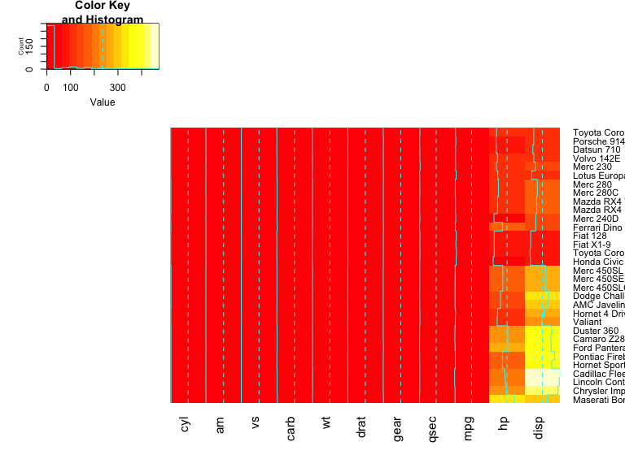

```r
heatmap.2(x, dendrogram="none") ##  no dendrogram plotted, but reordering done.
```

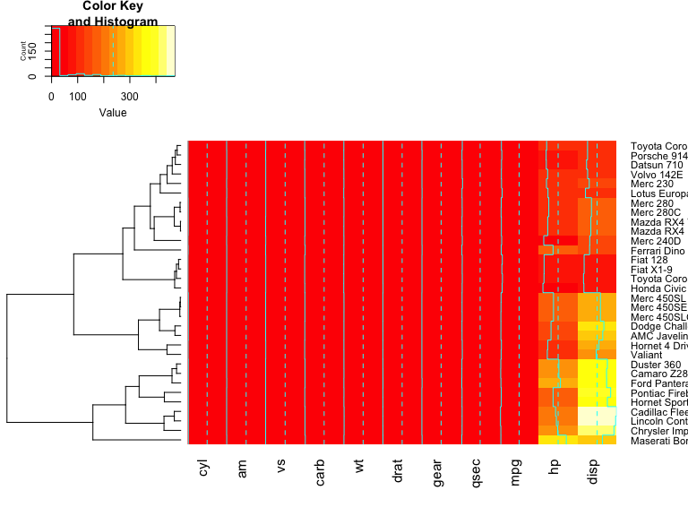

```r
heatmap.2(x, dendrogram="row")  ## row dendrogram plotted and row reordering done.
```

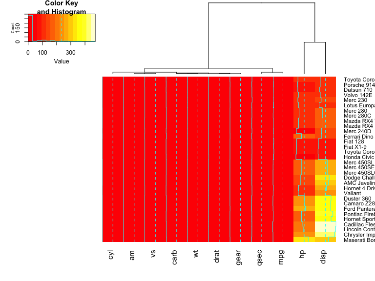

```r
heatmap.2(x, dendrogram="col")  ## col dendrogram plotted and col reordering done.
```

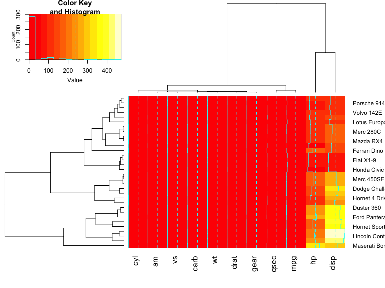

```r
heatmap.2(x, keysize=2)         ## default - dendrogram plotted and reordering done.
```

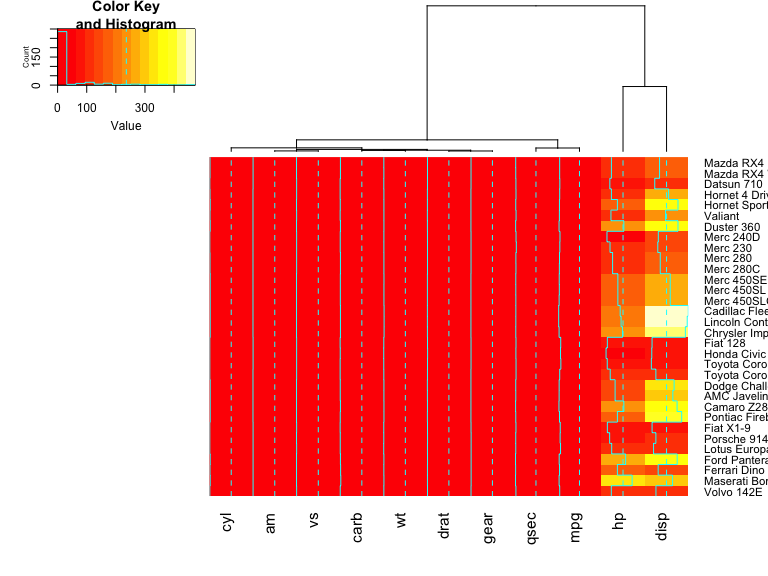

```r
heatmap.2(x, Rowv=FALSE, dendrogram="both") ## generates a warning!
```

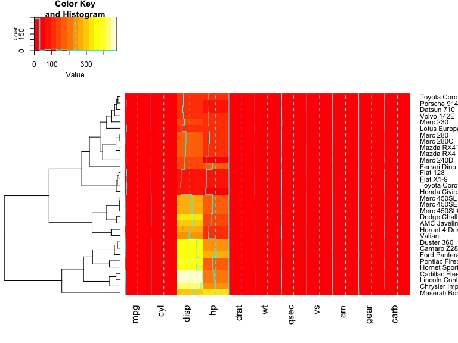

```r
heatmap.2(x, Rowv=NULL, dendrogram="both")  ## generates a warning!
heatmap.2(x, Colv=FALSE, dendrogram="both") ## generates a warning!
```

[output not shown]

## Reorder dendrogram by branch means rather than sums

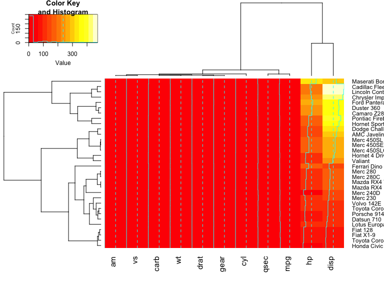

```r
heatmap.2(x, reorderfun=function(d, w) reorder(d, w, agglo.FUN = mean) )
```

## Color dendrograms’ branches (using dendextend)

```r
full <- heatmap.2(x) # we use it to easily get the dendrograms
```

[output not shown]

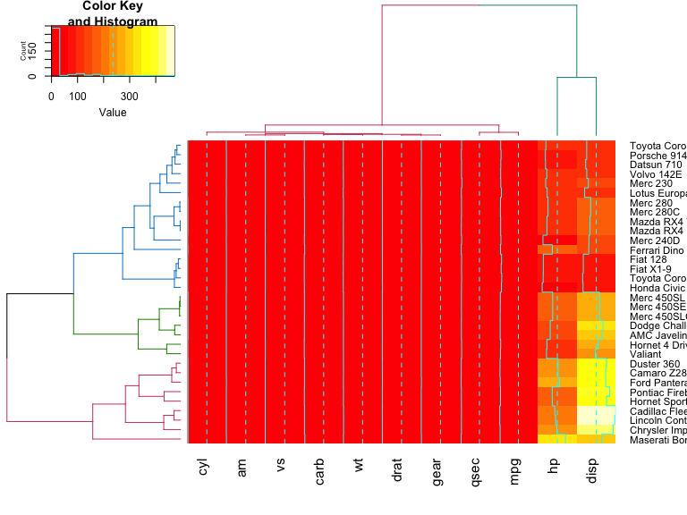

```r
library(dendextend)  # for color_branches
heatmap.2(x,
        Rowv=color_branches(full$rowDendrogram, k = 3),
        Colv=color_branches(full$colDendrogram, k = 2))
```

```r
# Look at the vignette for more details:
# https://cran.r-project.org/web/packages/dendextend/vignettes/dendextend.html
```

## plot a sub-cluster using the same color coding as for the full heatmap

```r
full <- heatmap.2(x)
```

[output not shown]

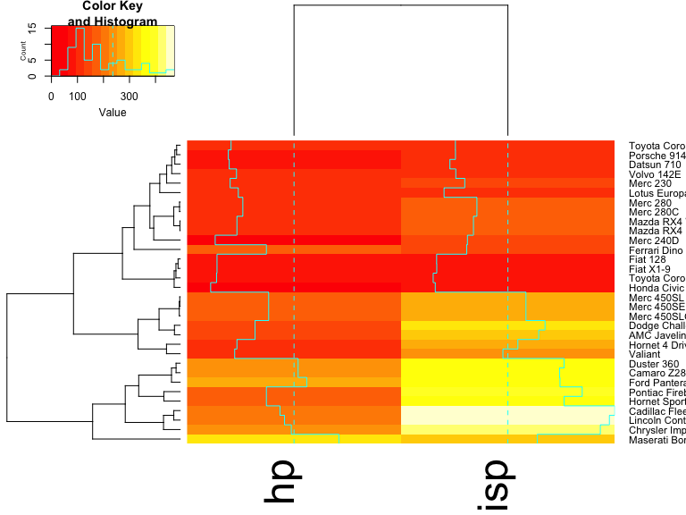

```r
heatmap.2(x, Colv=full$colDendrogram[[2]], breaks=full$breaks)  # column subset
```

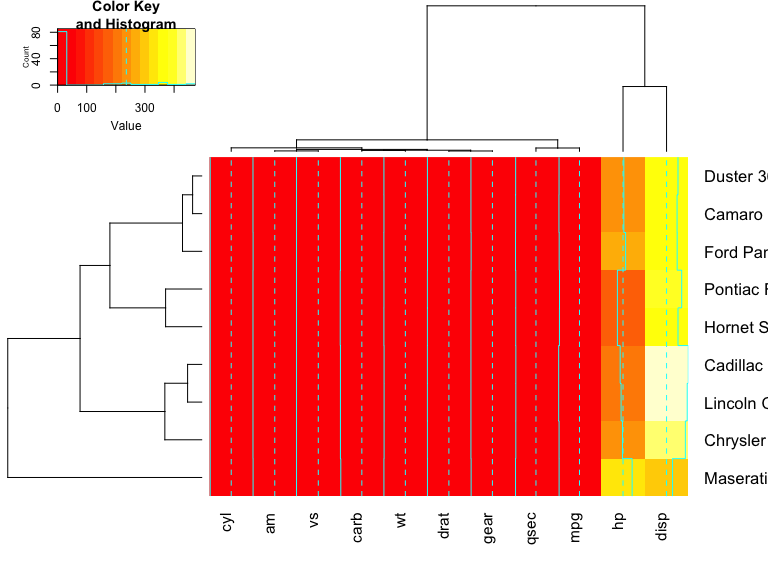

```r
heatmap.2(x, Rowv=full$rowDendrogram[[1]], breaks=full$breaks)  # row subset
```

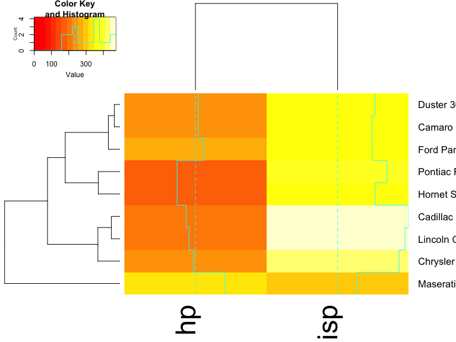

```r
heatmap.2(x, Colv=full$colDendrogram[[2]],
            Rowv=full$rowDendrogram[[1]], breaks=full$breaks)  # both
```

# Show effect of row and column label rotation

```r
heatmap.2(x, srtCol=NULL)
```

[output not shown]

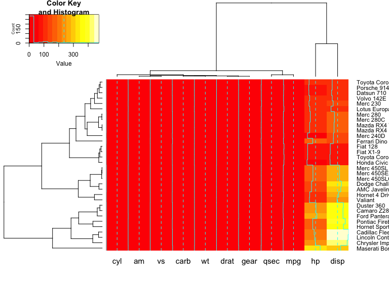

```r
heatmap.2(x, srtCol=0,   adjCol = c(0.5,1) )
```

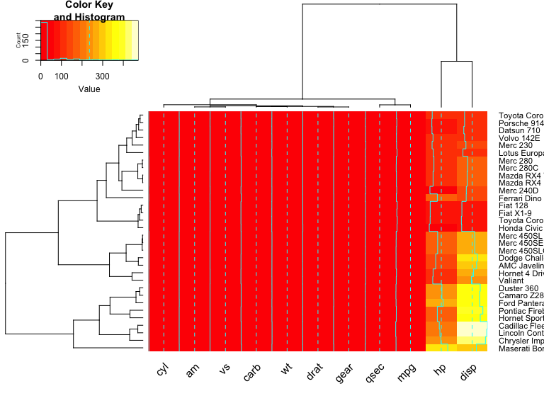

```r
heatmap.2(x, srtCol=45,  adjCol = c(1,1)   )
```

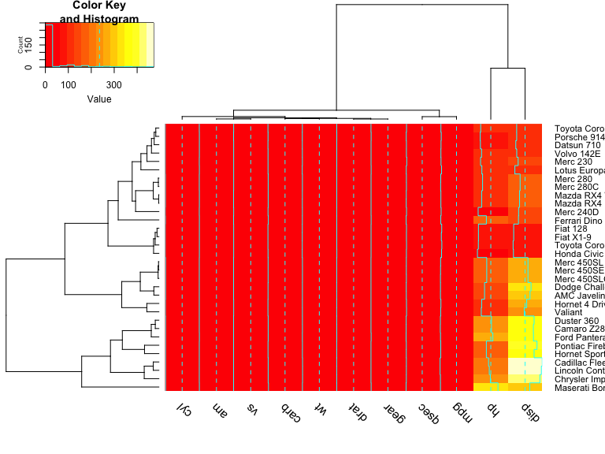

```r
heatmap.2(x, srtCol=135, adjCol = c(1,0)   )
```

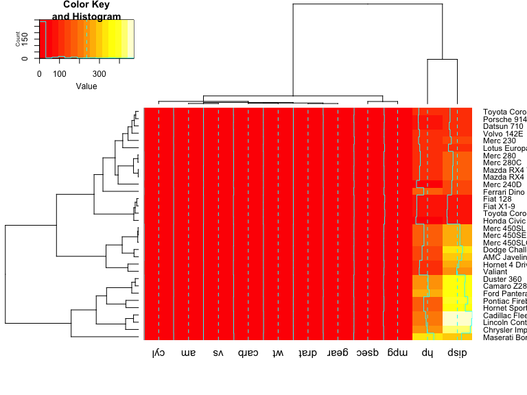

```r
heatmap.2(x, srtCol=180, adjCol = c(0.5,0) )
```

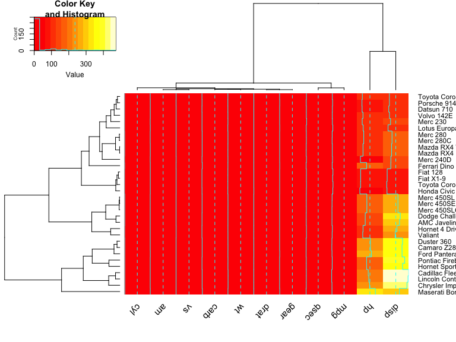

```r
heatmap.2(x, srtCol=225, adjCol = c(0,0)   ) ## not very useful
```

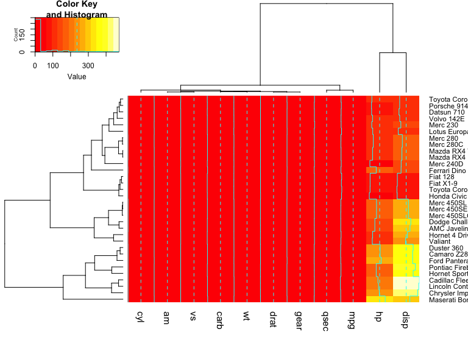

```r
heatmap.2(x, srtCol=270, adjCol = c(0,0.5) )
```

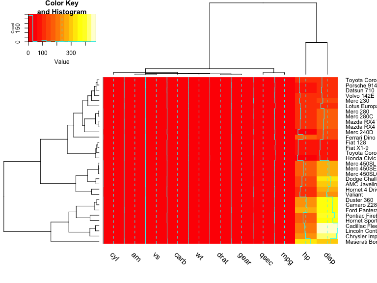

```r
heatmap.2(x, srtCol=315, adjCol = c(0,1)   )
```

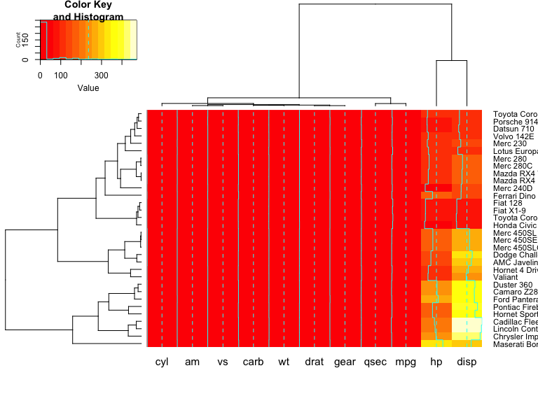

```r
heatmap.2(x, srtCol=360, adjCol = c(0.5,1) )
```

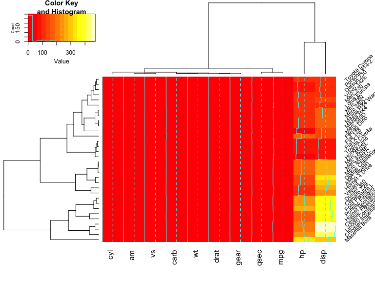

```r
heatmap.2(x, srtRow=45, adjRow=c(0, 1) )
```

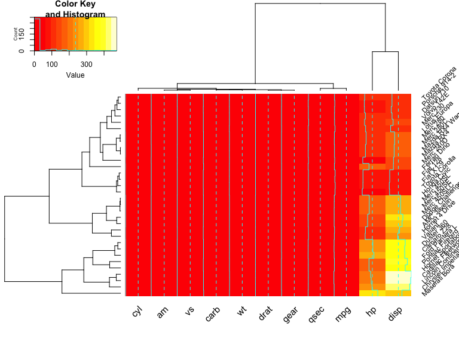

```r
heatmap.2(x, srtRow=45, adjRow=c(0, 1), srtCol=45, adjCol=c(1,1) )
```

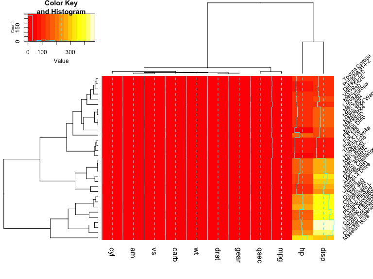

```r
heatmap.2(x, srtRow=45, adjRow=c(0, 1), srtCol=270, adjCol=c(0,0.5) )
```